# Q-learning

Jan Sviták, Rob van der Noll

January 28, 2020

In this notebook we present the simulations with Q-learning algorithms solving the full reinforcement learning problem.

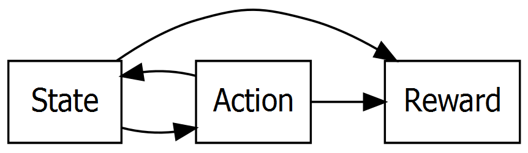

## Q-learning

As is the case with all the previously presented algorithms also Q-learning algorithms will estimate expected reward for each available option given the observed state. This expected reward is referred to as a Q-value.

The Q-learning algorithms are strategic in the sense that they take into account what the consequences of their actions are for future states and rewards. The goal is to maximise the net present value of the sum of profits over the duration of the game. This optimalization problem is solved using a Bellman equation which uses the logic of backwards induction and leads to a Q-value for state $s$ and action $a$ defined as:

$$Q(s,a)=\mathbb{E}[\pi | s, a] + \gamma \mathbb{E}[\max_a Q(s', a)|s, a]$$
where $\pi$ is the profit for the state $s$ and action $a$, $\gamma$ is the discount factor and $s'$ is the state of the world in the following period.

The Q-value is estimated iteratively as follows:

$$Q'(s_t,a_t) = (1-\alpha)Q(s_t,a_t)+\alpha \left(\pi_t+\gamma \max_a Q(s_{t+1}, a)\right)$$

where $\alpha$ determines the learning rate. High alpha means that recently observed profits has a large effect on the updated Q-value.

To facilitate exploration, we use an $\epsilon$-greedy strategy and let the firms choose a price randomly with probability $e^{-0.00001t}$. The exploration probability decreases with time, so the change of choosing a random price is approximately 99% after 1000 periods and 13% after 200000 periods. We initialise the Q-tables with the actual profits for given combination of prices so the starting strategies would lead the firm to the Nash equilibrium. The initial state is a random draw from the set of prices for both firms.

We proceed by writing the function carrying out the simulation:

```r
#inputs of the function are:
#   vector of available prices (P),
#   the intercept of the logit model (alpha),
#   the price sensitivity parameter of the logit model (beta),
#   the discount factor (gamma),
#   the learning rate (lr).
#   number of iterations in one experiment (N).
#   number of experiments (MC)
simulate <- function(P, alpha, beta, gamma, lr, N, MC){
  #collect prices
  prices1 <- matrix(rep(NA, N*MC), N, MC)
  prices2 <- matrix(rep(NA, N*MC), N, MC)
  #collect profits
  profits1 <- matrix(rep(NA, N*MC), N, MC)
  profits2 <- matrix(rep(NA, N*MC), N, MC)
  #collect Q-tables
  Q1list <- Q2list <- list()
  #number of available prices
  l <- length(P)
  #loop over experiments
  for (mc in 1:MC){
    #initialize
    #all combinations of prices
    P_matrix <- data.frame(x1 = rep(P, each = l^2),
                                       x2 = rep(P, l^2))
    #Q-tables correspond to the associated profits
    Q1 <- Q2 <- matrix(P_matrix$x2*exp(alpha - beta*P_matrix$x2)/
                         (1 + exp(alpha - beta*P_matrix$x2) + exp(alpha - beta*P_matrix$x1)), l^2, l, byrow = TRUE)
    #random draw for both firms
    pull1 <- sample(P, 1)
    pull2 <- sample(P, 1)
    #collect prices
    prices1[1, mc] <- pull1
    prices2[1, mc] <- pull2
    #collect profits
    profits1[1, mc] <- pull1*exp(alpha - beta * pull1)/
      (1 + exp(alpha - beta * pull1) + exp(alpha - beta * pull2))
    profits2[1, mc] <- pull2*exp(alpha - beta * pull2)/
      (1 + exp(alpha - beta * pull1) + exp(alpha - beta * pull2))
    #loop over periods
    for (t in 2:N){
      #observe the state of the world (prices in previous period)
      s1 <- (which(P==pull2)-1)*l + which(P==pull1)
      s2 <- (which(P==pull1)-1)*l + which(P==pull2)
      #exploration probability
      eps <- exp(-0.00001*t)
      #exploration decision firm 1
      exp1 <- sample(c(0, 1), prob = c(1 - eps, eps), 1)
      #exploration decision firm 2
      exp2 <- sample(c(0, 1), prob = c(1 - eps, eps), 1)
      #explore (random price)
      if(exp1){
        pull1 <- sample(P, 1)
      }
      #choose best reponse to competitor's price in previous period
      else{
        pull1 <- P[which.max(Q1[s1,])]
      }
      #explore (random price)
      if(exp2){
        pull2 <- sample(P, 1)
      }
      #choose best reponse to competitor's price in previous period
      else{
        pull2 <- P[which.max(Q2[s2,])]
      }
      #action firm 1
      a1 <- which(P==pull1)
      #action firm 2
      a2 <- which(P==pull2)
      #collect prices
      prices1[t, mc] <- pull1
      prices2[t, mc] <- pull2
      #collect profits
      profits1[t, mc] <- pull1*exp(alpha - beta * pull1)/(1 + exp(alpha - beta * pull1) + exp(alpha - beta * pull2))
      profits2[t, mc] <- pull2*exp(alpha - beta * pull2)/(1 + exp(alpha - beta * pull1) + exp(alpha - beta * pull2))
      #update Q-tables
      Q1[s1, a1] <- (1 - lr)*Q1[s1, a1] +
        lr*(profits1[t, mc] + gamma*max(Q1[(which(P==pull2)-1)*l + which(P==pull1),]))
      Q2[s2, a2] <- (1 - lr)*Q2[s2, a2] +
        lr*(profits2[t, mc] + gamma*max(Q2[(which(P==pull1)-1)*l + which(P==pull2),]))
    }
    #collect resulting Q-tables
    Q1list[[mc]] <- Q1
    Q2list[[mc]] <- Q2
  }
  #save results in the environment
  prices1 <<- prices1
  prices2 <<- prices2
  profits1 <<- profits1
  profits2 <<- profits2
  Q1list <<- Q1list
  Q2list <<- Q2list
}
```

We run 100 experiments of 1500000 periods with learning rate of 0.05 and discount factor of 0.95.

```r
#available prices
P <- seq(0.1, 1, 0.1)
#run
simulate(P = P, alpha = 5, beta = 5, gamma = 0.95, lr = 0.05, N = 1500000, MC = 100)
```

## Simulation results

Let’s visualise the results from the simulations:

```r
#load function
load("plot.RData")
#generate panels (select every 100th period to speed up)
plot_sim(prices1[seq(1, 1500000, 100),], prices2[seq(1, 1500000, 100),], P)
#construct left panel
tmp <- ggplot_gtable(ggplot_build(g1))
#identify element containing legend
leg <- which(sapply(tmp$grobs, function(x) x$name) == "guide-box")
#extract legend
legend <- tmp$grobs[[leg]]
```

```r
#adjust the periods (due to selection of periods)
g1 <- g1 + scale_x_continuous(labels = c(0, "500000", "1000000", 1500000))
#arrange left and right panel with common legend underneath
png(filename = "Fig10.png", width = 1200, height = 650, pointsize = 12, res = 150)
grid.arrange(arrangeGrob(g1 + theme(legend.position = "none"),
                         g2 + theme(legend.position = "none"), nrow = 1),
             legend, nrow = 2, heights = c(10, 2))
dev.off()
```

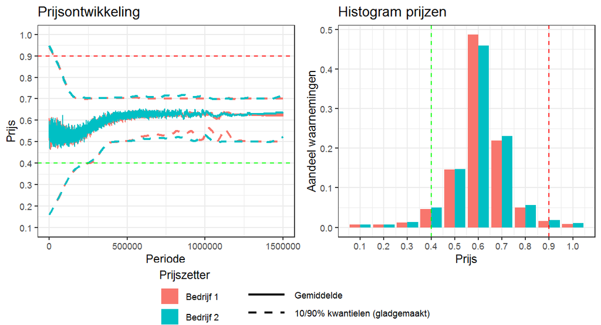

We can see that the prices converge to prices above the competitive equilibrium (mostly 0.6 or 0.7). The results appear to be stable across experiments.

We note that the number of iterations needed for convergence to the supra-competitive equilibrium large is. Calvano et al. (2019) suggest that the algorithms could be trained offline - i.e. in a simulation. The trained algorithm could then be deployed for price-setting in real markets. We explore the feasibility of this idea.

First, we investigate whether the two algorithms in each experiment learn strategies that are similar. We will calculate correlation in firms’ best response for each state of the world. A high correlation would indicate that the algorithms react the same way in identical situations. Low correlation shows, on the other hand, that the two algorithms behave differently.

```r
#vector of correlations (100 experiments)
r <- rep(NA, 100)
for(i in 1:100){
  r[i] <- cor(P[apply(Q1list[[i]], 1, FUN = function(x) {which.max(x)})],
              P[apply(Q2list[[i]], 1, FUN = function(x) {which.max(x)})])
}
#average correlation
mean(r)
```

```
[1] 0.1669138
```

The average correlation is 0.17 which seems rather low. The histogram below confirms that the correlations are low in general across experiments.

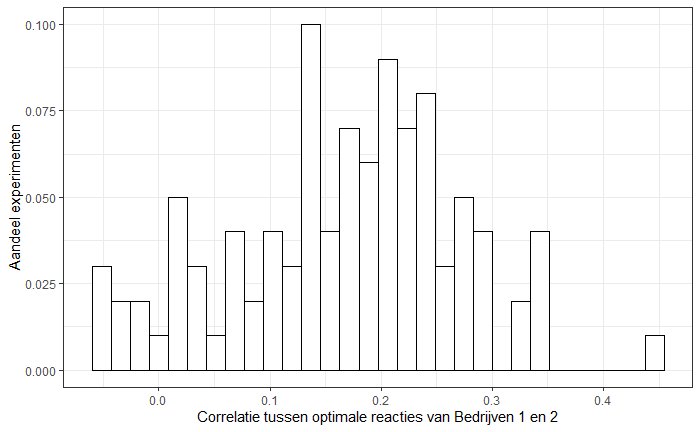

```r
#plot histogram of correlations
ggplot(data = data.frame(r = r)) +
  #bars as counts divided by 100 (number of experiments)
  geom_bar(aes(x = r, y = ..count../100), stat = "bin", fill = "white", colour = "black") +
  #labels
  labs(x = "Correlatie tussen optimale reacties van Bedrijven 1 en 2",
       y = "Aandeel experimenten") +
  #black and white theme
  theme_bw()
```

The low correlations mean that the equilibria are reached through complementary strategies rather than similar ones. Therefore, it seems difficult to decide which of the two different strategies resulting from the simulation to use for real world price-setting.

## Example

We start with a Q-table of Firm 1:

```r
#prepare labels for part of the Q-tabel corresponding to prices 0.4, 0.5, 0.6
x_label <- paste(rep(c(0.4, 0.5, 0.6), 3))
x_label[c(2, 5, 8)] <- paste0("p2: ", c(0.4, 0.5, 0.6), ",  p1: ", x_label[c(2, 5, 8)])
#Firm 1
g1 <- ggplot() +
  #color corresponding to Q-value
  geom_tile(data = reshape2::melt(Q1list[[4]][rep(4:6, 3)+rep(3:5, each = 3)*10, 4:6]),
            aes(x = Var2, y = Var1, fill = value)) +
  #invisible point to add optimal reaction to legend
  geom_point(data = data.frame(x = 1, y = 1, t = "Optimale reactie"), aes(x = x, y = y, color = t), shape = NA) +
  #color palette
  scale_fill_distiller(name = "Q-waarde", palette = "RdYlBu", limits = c(4.47, 5.62)) +
  #labels for y-axis (states of the world)
  scale_y_continuous(name = "Geobserveerde prijzen (vorige periode)",
                     breaks = 1:9, labels = x_label,
                     expand = c(0, 0)) +
  #labels for x axis (available prices)
  scale_x_continuous(name = "Acties Bedrijf 1",
                     breaks = 1:3, labels = seq(0.4, 0.6, 0.1),
                     expand = c(0.01, 0)) +
  #horizontal lines dividing the Q-table according to competitor's prices
  geom_hline(yintercept = 0.5) +
  geom_hline(yintercept = 3.5) +
  geom_hline(yintercept = 6.5) +
  geom_hline(yintercept = 9.5) +
  #highlight optimal reactions
  geom_encircle(data = data.frame(x1 = rep(c(0.62, 1.38), 2),
                                  x2 = c(rep(0.65, 2), rep(1.35, 2))),
                aes(x = x2, y = x1), color="green2", s_shape=0.9, size=2, expand = 0.05) +
  geom_encircle(data = data.frame(x1 = rep(c(1.62, 2.38), 2),
                                  x2 = c(rep(2.65, 2), rep(3.35, 2))),
                aes(x = x2, y = x1), color="green2", s_shape=0.9, size=2, expand = 0.05) +
  geom_encircle(data = data.frame(x1 = rep(c(2.62, 3.38), 2),
                                  x2 = c(rep(0.65, 2), rep(1.35, 2))),
                aes(x = x2, y = x1), color="green2", s_shape=0.9, size=2, expand = 0.05) +
  geom_encircle(data = data.frame(x1 = rep(c(3.62, 4.38), 2),
                                  x2 = c(rep(1.65, 2), rep(2.35, 2))),
                aes(x = x2, y = x1), color="green2", s_shape=0.9, size=2, expand = 0.05) +
  geom_encircle(data = data.frame(x1 = rep(c(4.62, 5.38), 2),
                                  x2 = c(rep(1.65, 2), rep(2.35, 2))),
                aes(x = x2, y = x1), color="green2", s_shape=0.9, size=2, expand = 0.05) +
  geom_encircle(data = data.frame(x1 = rep(c(5.62, 6.38), 2),
                                  x2 = c(rep(1.65, 2), rep(2.35, 2))),
                aes(x = x2, y = x1), color="green2", s_shape=0.9, size=2, expand = 0.05) +
  geom_encircle(data = data.frame(x1 = rep(c(6.62, 7.38), 2),
                                  x2 = c(rep(1.65, 2), rep(2.35, 2))),
                aes(x = x2, y = x1), color="green2", s_shape=0.9, size=2, expand = 0.05) +
  geom_encircle(data = data.frame(x1 = rep(c(7.62, 8.38), 2),
                                  x2 = c(rep(0.65, 2), rep(1.35, 2))),
                aes(x = x2, y = x1), color="green2", s_shape=0.9, size=2, expand = 0.05) +
  geom_encircle(data = data.frame(x1 = rep(c(8.62, 9.38), 2),
                                  x2 = c(rep(2.65, 2), rep(3.35, 2))),
                aes(x = x2, y = x1), color="green2", s_shape=0.9, size=2, expand = 0.05) +
  #adjust legend
  guides(
    #create legend key for optimal reactions
    color = guide_legend(
      override.aes = list(size = 10, stroke = 2, shape = 0, color = "green2")
    ),
    fill = guide_colourbar(order = 1)
  ) +
  #adjust panel background and legend key background
  theme(
    panel.background = element_rect(fill = NA),
    legend.key = element_blank(),
    #more space for labels on left side
    axis.text.y = element_text(hjust = 1, margin=margin(0,0,0,4)),
    axis.ticks.y = element_blank()
  ) +
  #no label for color
  labs(color = "")
```

We proceed analogically with Firm 2:

```r
#prepare labels for part of the Q-tabel corresponding to prices 0.4, 0.5, 0.6
x_label <- paste(rep(c(0.4, 0.5, 0.6), 3))
x_label[c(2, 5, 8)] <- paste0("p1: ", c(0.4, 0.5, 0.6), ",  p2: ", x_label[c(2, 5, 8)])
#Firm 2
g2 <- ggplot() +
  geom_tile(data = reshape2::melt(Q2list[[4]][rep(4:6, 3)+rep(3:5, each = 3)*10, 4:6]),
            aes(x = Var2, y = Var1, fill = value)) +
  #add invisible layer to add optimal reaction to legend
  geom_point(data = data.frame(x = 1, y = 1, t = "Optimale reactie"), aes(x = x, y = y, color = t), shape = NA) +
  #color palette
  scale_fill_distiller(name = "Q-waarde", palette = "RdYlBu", limits = c(4.47, 5.62)) +
  #labels y-axis
  scale_y_continuous(name = "Geobserveerde prijzen (vorige periode)",
                     breaks = 1:9, labels = x_label,
                     expand = c(0, 0)) +
  #labels x-axis
  scale_x_continuous(name = "Actie bedrijf 2",
                     breaks = 1:3, labels = seq(0.4, 0.6, 0.1),
                     expand = c(0.01, 0)) +
  #horizontal lines dividing the Q-table according to competitor's prices
  geom_hline(yintercept = 0.5) +
  geom_hline(yintercept = 3.5) +
  geom_hline(yintercept = 6.5) +
  geom_hline(yintercept = 9.5) +
  #highlight optimal reactions
  geom_encircle(data = data.frame(x1 = rep(c(0.62, 1.38), 2),
                                  x2 = c(rep(1.65, 2), rep(2.35, 2))),
                aes(x = x2, y = x1), color="green2", s_shape=0.9, size=2, expand = 0.05) +
  geom_encircle(data = data.frame(x1 = rep(c(1.62, 2.38), 2),
                                  x2 = c(rep(0.65, 2), rep(1.35, 2))),
                aes(x = x2, y = x1), color="green2", s_shape=0.9, size=2, expand = 0.05) +
  geom_encircle(data = data.frame(x1 = rep(c(2.62, 3.38), 2),
                                  x2 = c(rep(0.65, 2), rep(1.35, 2))),
                aes(x = x2, y = x1), color="green2", s_shape=0.9, size=2, expand = 0.05) +
  geom_encircle(data = data.frame(x1 = rep(c(3.62, 4.38), 2),
                                  x2 = c(rep(2.65, 2), rep(3.35, 2))),
                aes(x = x2, y = x1), color="green2", s_shape=0.9, size=2, expand = 0.05) +
  geom_encircle(data = data.frame(x1 = rep(c(4.62, 5.38), 2),
                                  x2 = c(rep(2.65, 2), rep(3.35, 2))),
                aes(x = x2, y = x1), color="green2", s_shape=0.9, size=2, expand = 0.05) +
  geom_encircle(data = data.frame(x1 = rep(c(5.62, 6.38), 2),
                                  x2 = c(rep(1.65, 2), rep(2.35, 2))),
                aes(x = x2, y = x1), color="green2", s_shape=0.9, size=2, expand = 0.05) +
  geom_encircle(data = data.frame(x1 = rep(c(6.62, 7.38), 2),
                                  x2 = c(rep(2.65, 2), rep(3.35, 2))),
                aes(x = x2, y = x1), color="green2", s_shape=0.9, size=2, expand = 0.05) +
  geom_encircle(data = data.frame(x1 = rep(c(7.62, 8.38), 2),
                                  x2 = c(rep(0.65, 2), rep(1.35, 2))),
                aes(x = x2, y = x1), color="green2", s_shape=0.9, size=2, expand = 0.05) +
  geom_encircle(data = data.frame(x1 = rep(c(8.62, 9.38), 2),
                                  x2 = c(rep(2.65, 2), rep(3.35, 2))),
                aes(x = x2, y = x1), color="green2", s_shape=0.9, size=2, expand = 0.05) +
  #adjust legend
  guides(
    color = guide_legend(
      override.aes = list(size = 10, stroke = 2, shape = 0, color = "green2")
    ),
    fill = guide_colourbar(order = 1)
  ) +
  #blank background, no tick marks
  theme(
    panel.background = element_rect(fill = NA),
    legend.key = element_blank(),
    axis.text.y = element_text(hjust = 1, margin=margin(0,0,0,4)),
    axis.ticks.y = element_blank()
  ) +
  labs(color = "")
```

We combine both panels in one figure.

```r
#construct left panel
tmp <- ggplot_gtable(ggplot_build(g1))
#identify element containing legend
leg <- which(sapply(tmp$grobs, function(x) x$name) == "guide-box")
#extract legend
legend <- tmp$grobs[[leg]]
```

```r
#arrange left and right panel with common legend on the right
png(filename="Fig11.png", width=1200, height=700,
    pointsize = 12, res = 150)
grid.arrange(arrangeGrob(g1 + theme(legend.position="none"),
                         g2 + theme(legend.position="none"), nrow = 1),
             legend, ncol=2, widths=c(20, 5))
dev.off()
```

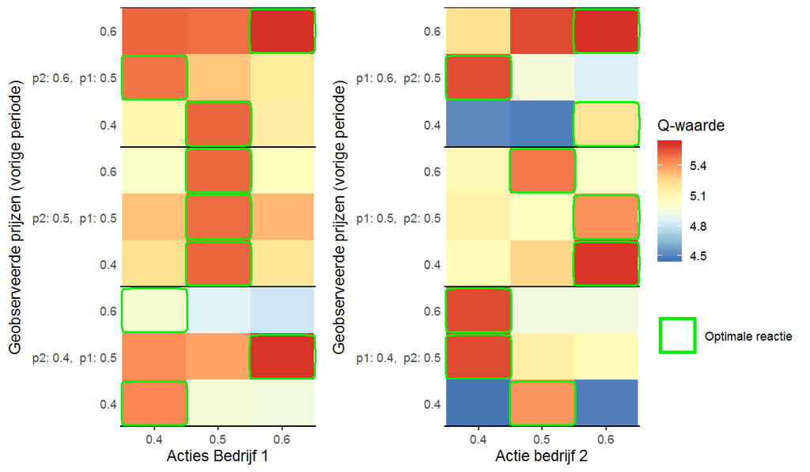

We can see that the optimal reactions are quite different between the two firms. For example, in Nash Equilibrium, Firm 1 keeps charging 0.4, but Firm 2 increases the prices to 0.5.

The above Q-tables lead to the following equilibrium path from the Nash equilibrium to the outcome with prices equal to 0.6. The strategies are, thus, in a way, complementary to each other.

```r
#all possible combinations of prices
P_matrix <- data.frame(x1 = rep(P, each = length(P)),
                       x2 = rep(P, length(P)))
#denominator of logit function
denom <- 1 + exp(5 - 5*P_matrix$x2) + exp(5 - 5*P_matrix$x1)
P_matrix$profit <- P_matrix$x2*exp(5 - 5*P_matrix$x2)/denom + P_matrix$x1*exp(5 - 5*P_matrix$x1)/denom
#save as png
png(filename="Fig12.png", width=900, height=700,
    pointsize = 12, res = 150)
ggplot() +
  #color based on aggregate profits
  geom_tile(data = P_matrix, aes(x = x2, y = x1, fill = profit)) +
  #color palette
  scale_fill_distiller(palette = "RdYlBu") +
  #invisible layer to get visited states into legend
  geom_point(data = data.frame(x = 1, y = 1, t = "Gehanteerde prijzen"),
             aes(x = x, y = y, color = t), shape = NA) +
  #label and tick marks y-axis
  scale_y_continuous(
    name = "Bedrijf 2",
    breaks = seq(0.1, 1, 0.1),
    expand = c(0, 0)
  ) +
  #label and tick marks y-axis
  scale_x_continuous(
    name = "Bedrijf 1",
    breaks = seq(0.1, 1, 0.1),
    expand = c(0, 0)
  ) +
  #highlight visited states
  geom_encircle(data = data.frame(x1 = rep(c(0.39, 0.41), 2),
                                  x2 = c(rep(0.39, 2), rep(0.41, 2))),
                aes(x = x2, y = x1),
                color="green2", s_shape=0.9,size=3, expand = 0.05) +
  geom_encircle(data = data.frame(x1 = rep(c(0.49, 0.51), 2),
                                  x2 = c(rep(0.39, 2), rep(0.41, 2))),
                aes(x = x2, y = x1),
                color="green2", s_shape=0.9,size=3, expand = 0.05) +
  geom_encircle(data = data.frame(x1 = rep(c(0.39, 0.41), 2),
                                  x2 = c(rep(0.49, 2), rep(0.51, 2))),
                aes(x = x2, y = x1),
                color="green2", s_shape=0.9,size=3, expand = 0.05) +
  geom_encircle(data = data.frame(x1 = rep(c(0.59, 0.61), 2),
                                  x2 = c(rep(0.59, 2), rep(0.61, 2))),
                aes(x = x2, y = x1),
                color="green2", s_shape=0.9,size=3, expand = 0.05) +
  #add the final feedback loop (transition)
  geom_curve(aes(x = 0.62, xend = 0.58), y = 0.62, yend = 0.62, curvature = 4,
               col = "white", size = 2, arrow = arrow(length = unit(0.2, "cm"))) +
  geom_curve(aes(x = 0.62, xend = 0.58), y = 0.62, yend = 0.62, curvature = 4,
               col = "black", size = 1, arrow = arrow(length = unit(0.2, "cm"))) +
  #add transitions between states (black arrow over a thicker white arrow)
  geom_segment(aes(x = 0.5, xend = 0.6), y = 0.4, yend = 0.6,
               col = "white", size = 2, arrow = arrow(length = unit(0.2, "cm"))) +
  geom_segment(aes(x = 0.5, xend = 0.6), y = 0.4, yend = 0.6,
               col = "black", size = 1, arrow = arrow(length = unit(0.2, "cm"))) +
  geom_segment(aes(x = 0.4, xend = 0.5), y = 0.5, yend = 0.4,
               col = "white", size = 2, arrow = arrow(length = unit(0.2, "cm"))) +
  geom_segment(aes(x = 0.4, xend = 0.5), y = 0.5, yend = 0.4,
               col = "black", size = 1, arrow = arrow(length = unit(0.2, "cm"))) +
  geom_segment(aes(x = 0.4, xend = 0.4), y = 0.41, yend = 0.5,
               col = "white", size = 2, arrow = arrow(length = unit(0.2, "cm"))) +
  geom_segment(aes(x = 0.4, xend = 0.4), y = 0.41, yend = 0.5,
               col = "black", size = 1, arrow = arrow(length = unit(0.2, "cm"))) +
  #blank background
  theme(panel.background = element_rect(fill = NA),
        legend.key = element_blank()) +
  #adjust labels
  labs(fill = "Gezamenlijke winst", color = "", title = "Voorbeeld van pad naar evenwicht") +
  #adjust legend
  guides(
    color = guide_legend(
      override.aes = list(size = 10, stroke = 2, shape = 0, color = "green2")
    ),
    fill = guide_colourbar(order = 1)
  ) +
  #annonate startpoint and outcome
  annotate("text", x = 0.4, y = 0.405, label = "Competitieve evenwicht", size = 3) +
  annotate("text", x = 0.6, y = 0.605, label = "Uitkomst", size = 3)
dev.off()
```

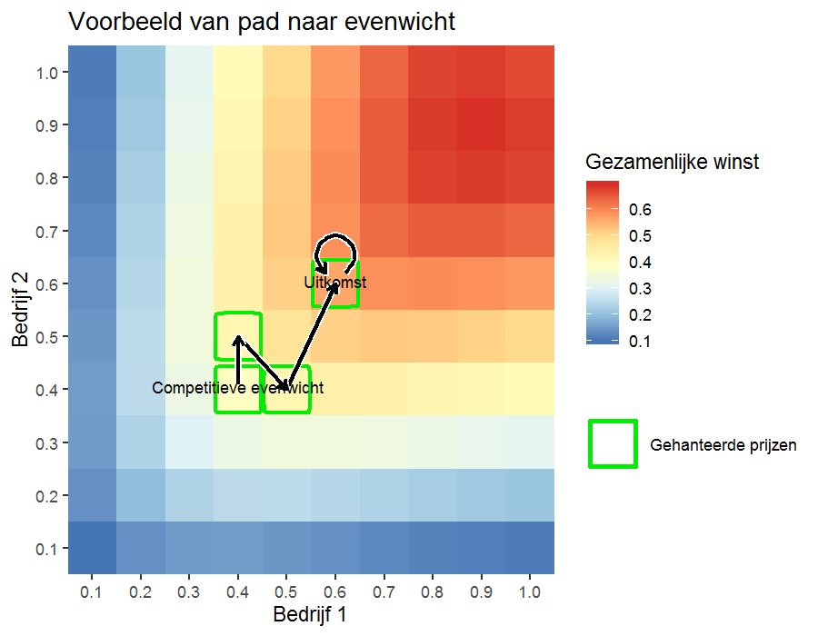

## Smaller choiceset

Let’s look how quick the convergence when we limit the choice set.

We adjust the function carrying out the simulation (the exploration probability changes).

```r
#inputs of the function are:
#   vector of available prices (P),
#   the intercept of the logit model (alpha),
#   the price sensitivity parameter of the logit model (beta),
#   the discount factor (gamma),
#   the learning rate (lr).
#   number of iterations in one experiment (N).
#   number of experiments (MC)
simulate_small <- function(P, alpha, beta, gamma, lr, N, MC){
  #collect prices
  prices1 <- matrix(rep(NA, N*MC), N, MC)
  prices2 <- matrix(rep(NA, N*MC), N, MC)
  #collect profits
  profits1 <- matrix(rep(NA, N*MC), N, MC)
  profits2 <- matrix(rep(NA, N*MC), N, MC)
  #collect Q-tables
  Q1list <- Q2list <- list()
  #number of available prices
  l <- length(P)
  #loop over experiments
  for (mc in 1:MC){
    #initialize
    #all combinations of prices
    P_matrix <- data.frame(x1 = rep(P, each = l^2),
                                       x2 = rep(P, l^2))
    #Q-tables correspond to the associated profits
    Q1 <- Q2 <- matrix(P_matrix$x2*exp(alpha - beta*P_matrix$x2)/
                         (1 + exp(alpha - beta*P_matrix$x2) + exp(alpha - beta*P_matrix$x1)), l^2, l, byrow = TRUE)
    #random draw for both firms
    pull1 <- sample(P, 1)
    pull2 <- sample(P, 1)
    #collect prices
    prices1[1, mc] <- pull1
    prices2[1, mc] <- pull2
    #collect profits
    profits1[1, mc] <- pull1*exp(alpha - beta * pull1)/
      (1 + exp(alpha - beta * pull1) + exp(alpha - beta * pull2))
    profits2[1, mc] <- pull2*exp(alpha - beta * pull2)/
      (1 + exp(alpha - beta * pull1) + exp(alpha - beta * pull2))
    #loop over periods
    for (t in 2:N){
      #observe the state of the world (prices in previous period)
      s1 <- (which(P==pull2)-1)*l + which(P==pull1)
      s2 <- (which(P==pull1)-1)*l + which(P==pull2)
      #exploration probability
      eps <- exp(-0.0005*t)
      #exploration decision firm 1
      exp1 <- sample(c(0, 1), prob = c(1 - eps, eps), 1)
      #exploration decision firm 2
      exp2 <- sample(c(0, 1), prob = c(1 - eps, eps), 1)
      #explore (random price)
      if(exp1){
        pull1 <- sample(P, 1)
      }
      #choose best reponse to competitor's price in previous period
      else{
        pull1 <- P[which.max(Q1[s1,])]
      }
      #explore (random price)
      if(exp2){
        pull2 <- sample(P, 1)
      }
      #choose best reponse to competitor's price in previous period
      else{
        pull2 <- P[which.max(Q2[s2,])]
      }
      #action firm 1
      a1 <- which(P==pull1)
      #action firm 2
      a2 <- which(P==pull2)
      #collect prices
      prices1[t, mc] <- pull1
      prices2[t, mc] <- pull2
      #collect profits
      profits1[t, mc] <- pull1*exp(alpha - beta * pull1)/(1 + exp(alpha - beta * pull1) + exp(alpha - beta * pull2))
      profits2[t, mc] <- pull2*exp(alpha - beta * pull2)/(1 + exp(alpha - beta * pull1) + exp(alpha - beta * pull2))
      #update Q-tables
      Q1[s1, a1] <- (1 - lr)*Q1[s1, a1] +
        lr*(profits1[t, mc] + gamma*max(Q1[(which(P==pull2)-1)*l + which(P==pull1),]))
      Q2[s2, a2] <- (1 - lr)*Q2[s2, a2] +
        lr*(profits2[t, mc] + gamma*max(Q2[(which(P==pull1)-1)*l + which(P==pull2),]))
    }
    #collect resulting Q-tables
    Q1list[[mc]] <- Q1
    Q2list[[mc]] <- Q2
  }
  #save results in the environment
  prices1 <<- prices1
  prices2 <<- prices2
  profits1 <<- profits1
  profits2 <<- profits2
  Q1list <<- Q1list
  Q2list <<- Q2list
}
```

```r
#run
simulate_small(P = c(0.3, 0.4, 0.5), alpha = 5, beta = 5, gamma = 0.95, lr = 0.5, N = 20000, MC = 100)
```

```r
#generate panels
plot_sim_small(prices1, prices2, c(0.3, 0.4, 0.5))

#construct left panel
tmp <- ggplot_gtable(ggplot_build(g1))
#identify element containing legend
leg <- which(sapply(tmp$grobs, function(x) x$name) == "guide-box")
#extract legend
legend <- tmp$grobs[[leg]]
```

```r
png(filename = "Fig_extra3.png", width = 1200, height = 650, pointsize = 12, res = 150)
#arrange left and right panel with common legend underneath
grid.arrange(arrangeGrob(g1 + theme(legend.position="none"),
                         g2 + theme(legend.position="none"), nrow = 1),
             legend, nrow=2, heights=c(10, 2))
```

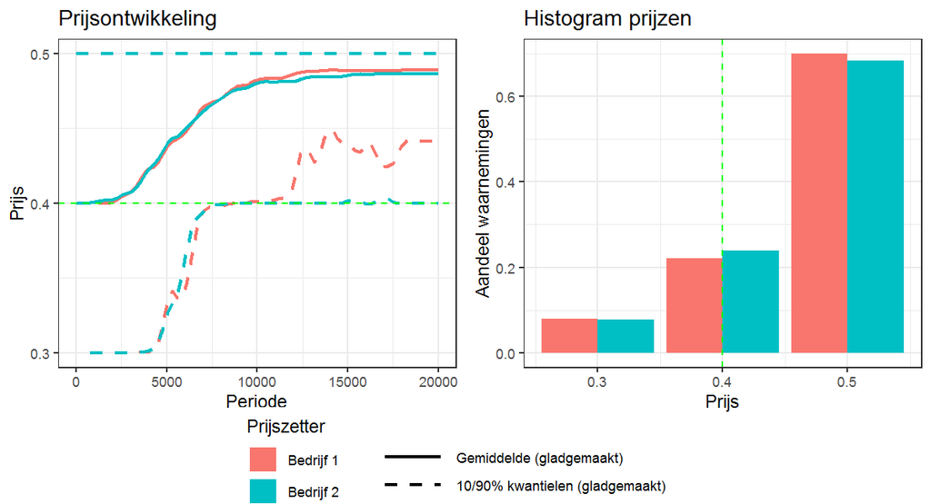

The convergence to the higher price is indeed much faster.